# Projects

# The Contraception Project

In the landscape of reproductive health, a notable transformation has been unfolding in Germany over the past decades. The pill, once perceived as the pinnacle of hormonal contraception, has experienced a significant decline in popularity. Our latest findings reveal a remarkable shift in the contraceptive choices of women in Germany, highlighting a growing preference for non-hormonal contraception methods.

based on data from the German Family Panel (pairfam) spanning from 2008 to 2021, we reveal a remarkable shift in the contraceptive choices of women in Germany

Observing women’s contraceptive behavior in data from the German Family Panel (pairfam) from 2008 to 2021, we witness a substantial decline in hormonal contraception. This can be largely ascribed to the pill losing its dominance as the primary method. Whereas nearly 80% of women relied on hormonal contraception to manage their reproductive health, this number has plummeted to 45% by 2021.

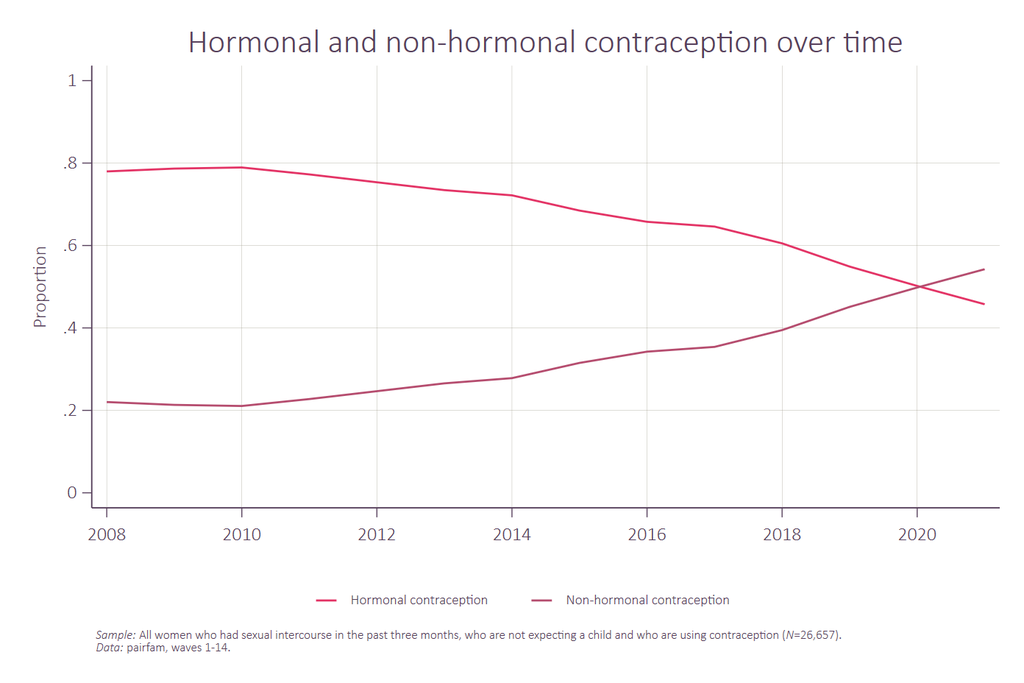

Is this increase in non-hormonal contraception equally driven by women across generations? We compared the contraceptive behavior of women born in the 1970s, 1980s, and 1990s, revealing an intriguing trend – the increasing popularity of non-hormonal contraception methods that transcends generational boundaries. Particularly women of the younger generations, who were observed during most of their reproductive years in their twenties and thirties, adapted their behavior. While nearly every contracepting woman in these generations used hormonal methods (ranging to 80-90% in 2008), the decline of hormonal methods in the 2010s was steady and accompanied by a steep increase in non-hormonal options.

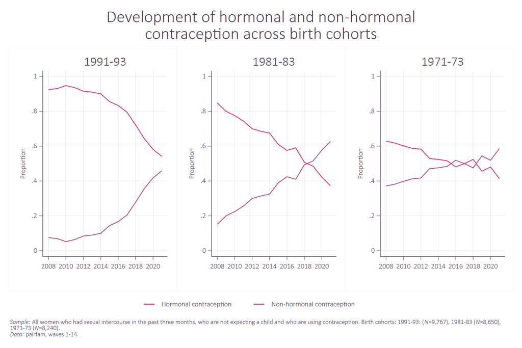

Find more information and insights on our current research on contraceptive behavior and decisions under [The Contraception Project](https://projectcontraception.github.io).